# Effect of USP39 knockdown on splicing

Mario Keller

Faculty of Biological Sciences, Goethe University Frankfurt

2 May 2023

```r
library(tidyverse)
library(knitr)
library(ggpubr)
library(ggsci)
library(ggpointdensity)
library(viridis)
library(patchwork)
library(ggvenn)
library(ggrastr)
library(ggupset)
library(ComplexHeatmap)
library(circlize)
library(GenomicRanges)
library(ggbeeswarm)
library(rtracklayer)
library(BSgenome.Hsapiens.UCSC.hg38)
```

```r
myTheme <- theme_bw() +
    theme(axis.text = element_text(size = 14, colour="black"),
          axis.title = element_text(size=16, colour="black"),
          axis.ticks=element_line(color="black"),
          axis.ticks.length=unit(.15, "cm"),
          panel.border=element_rect(color="black", fill = NA),
          panel.background = element_blank(),
          plot.background = element_blank(),
          legend.text = element_text(size=12),
          legend.position = "none")
```

# 1 Background

Based on the Voila modulizer output the effect of USP39 knockdown should be analyzed.

# 2 Data

Binary events are loaded from binaryEventsByModulizer.rds, which was generated with modulizer_output_to_rds.R. The loaded list contains 14 data.frames (one for each AS event class) with splicing quantifications.

```r
binaryEvents <- readRDS("rds_files/binaryEventsByModulizer.rds")
```

# 3 Identification of regulated splicing events

The identification of regulated events is still a little bit challenging and is a trade-off between being too stringent and loosing actually regulated events and being too loose and include false positives.

The 14 data.frames of the AS event classes have for each event either 2 or 4 rows. The number of rows depends on the number of LSVs that describe the AS event. For instance, cassette exon events are viewed from a source and target LSV perspective and we have for each of the LSVs two junctions (C1_C2 + C1_A and C2_C1 + C2_A), which are given as a row. On the other hand intron retention events are viewed only from a single LSV perspective, which is why we have just two junctions involved (C1_C2_intron + C1_C2_spliced or C2_C1_intron + C2_C1_spliced).

My current workflow is the following:

- Identify for each of the 14 AS event classes regulated events
  - Events with 2 junctions: Both junctions must have Prob(dPSI>=0.05) >= 0.9 and abs(dPSI>=0.1)
  - Events with 4 junctions: At least two junctions of the same LSV must have Prob(dPSI>=0.05) >= 0.9 and all junctions abs(dPSI>=0.1)
  - All pairs of junctions must have inverse regulation (execept for the multi exon spanning class*)
  - Within junction pairs, the the lower |dPSI| must bet at least 50% of the higher |dPSI|

Note: *For the multi exon spanning class the the dPSI of the proximal junctions is the same as the dPSI of the distal junctions. Probably a bug as they could have provided the correct dPSI.

```r
regulatedEvents <- lapply(names(binaryEvents), function(eventClass){

    eventsClassDf <- binaryEvents[[eventClass]]

    df <- eventsClassDf %>%
        dplyr::select(gene_name, module_id, event_id, lsv_id,
                      KD.CT_probability_changing, KD.CT_median_dpsi)

    notFullyQuantified <- df %>%
        dplyr::filter(., is.na(KD.CT_probability_changing) |
                          is.na(KD.CT_median_dpsi)) %>%
        pull(event_id) %>%
        unique

    df <- df %>%
        dplyr::filter(!event_id %in% notFullyQuantified) %>%
        dplyr::filter(., !lsv_id == "") %>%
        group_by(event_id, lsv_id) %>%
        summarise(., gene_name = unique(gene_name), module_id = unique(module_id),
                  regulated= sum(KD.CT_probability_changing >= 0.9) == 2,
                  change = sum(abs(KD.CT_median_dpsi) >= 0.1) == 2,
                  opposite = sum(sign(KD.CT_median_dpsi)) == 0,
                  fraction = sum(abs(KD.CT_median_dpsi/max(abs(KD.CT_median_dpsi))) >= 0.5) == 2) %>%
        summarise(gene_name=unique(gene_name), module_id=unique(module_id),
                  regulated = any(regulated),
                  change=all(change),
                  opposite=all(opposite),
                  fraction=all(fraction))

    if(eventClass == "multi_exon_spanning"){
        df <- df %>% dplyr::filter(regulated, change, fraction) %>%
            dplyr::select(gene_name, module_id, event_id)
    } else {
        df <- df %>% dplyr::filter(regulated, change, opposite, fraction) %>%
            dplyr::select(gene_name, module_id, event_id)
    }

    if(nrow(df) == 0){
        df <- data.frame(eventClass=character(), gene_name=character(), module_id=character(), event_id=character())

    } else {
       df <- cbind(eventClass = eventClass, df)
    }

    return(df)
}) %>% bind_rows()
```

In the following, the number of events per AS event class is determined and events that are not of interest to us grouped as “other”.

```r
regulatedEventFrequencies <- regulatedEvents %>%
    dplyr::count(eventClass, name="Frequency")

kable(regulatedEventFrequencies, align="c")
```

| eventClass | Frequency |
| --- | --- |
| alt3prime | 46 |
| alt5prime | 952 |
| alternate_first_exon | 92 |
| alternate_last_exon | 70 |
| alternative_intron | 208 |
| cassette | 253 |
| multi_exon_spanning | 265 |
| mutually_exclusive | 1 |
| p_alt3prime | 3 |
| p_alt5prime | 18 |
| p_alternate_first_exon | 16 |
| p_alternate_last_exon | 24 |
| tandem_cassette | 8 |

```r
eventsOfInterest <- c("cassette", "alternative_intron", "multi_exon_spanning",
                      "alternate_first_exon", "alternate_last_exon",
                      "alt5prime", "alt3prime", "other")

regulatedEventFrequencies <- regulatedEventFrequencies %>%
    add_row(
        regulatedEventFrequencies %>% filter(!eventClass %in% eventsOfInterest)  %>%
            summarise(eventClass="other", Frequency = sum(Frequency)) %>%
            select(eventClass, Frequency)
) %>% filter(., eventClass %in% eventsOfInterest) %>%
    mutate(eventClass=factor(eventClass, levels=rev(eventsOfInterest)))
```

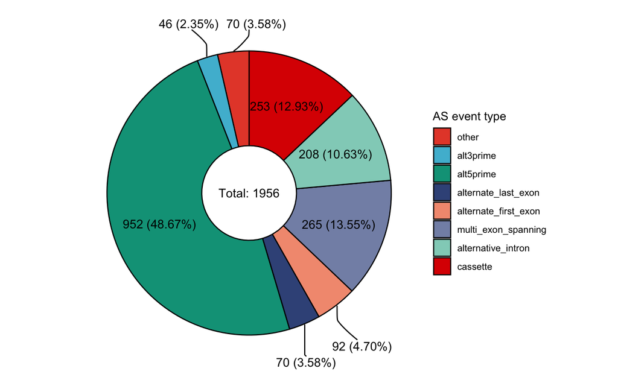

```r
regulatedEventFrequencies %>%
    mutate(eventClass=factor(eventClass)) %>%
    arrange(eventClass) %>%
    dplyr::rename(count="Frequency") %>%
    ggpie::ggdonut(., group_key = "eventClass", count_type = "count",
        label_info = "all", label_type = "horizon", label_split = NULL,
        label_size = 4, label_pos = "in", labal_threshold = 10,
        donut.label.color = "black") +
    scale_fill_npg(name="AS event type")
```

Roughly 50% of the regulated AS events correspond to A5SS events.

# 4 Focus on A5SS

## 4.1 Regulation of distal and proximal junctions

The regulation of the distal and proximal junctions is examined by plotting their usage (PSI) in the control and USP39 knockdown condition.

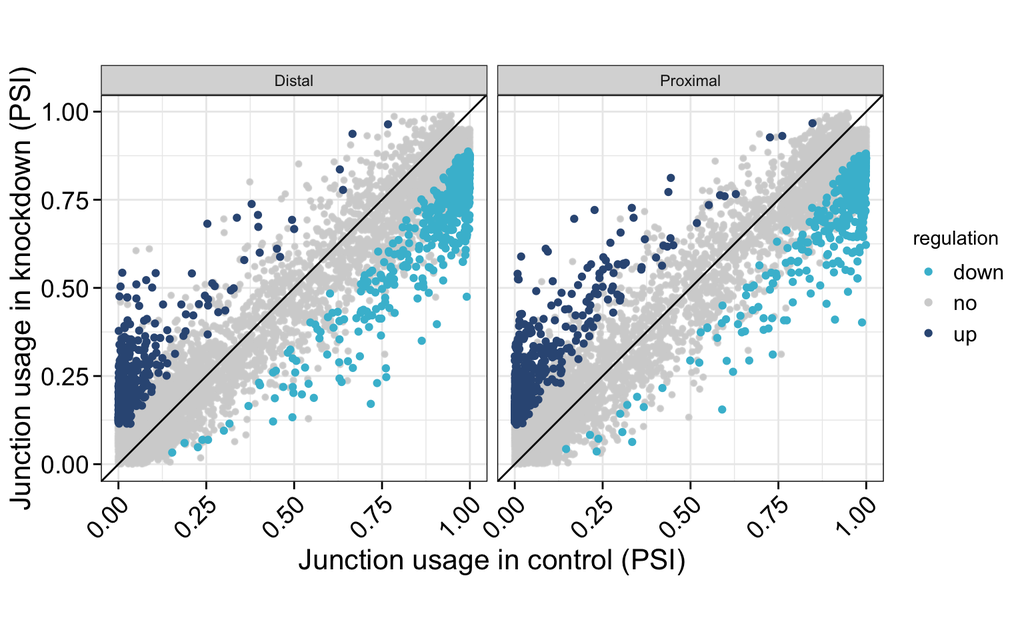

```r
regulationDF <- binaryEvents$alt5prime %>% dplyr::select(event_id, junction_name, CT_median_psi, KD_median_psi, KD.CT_median_dpsi, denovo) %>%
    mutate(regulation = case_when(event_id %in% regulatedEvents$event_id & KD.CT_median_dpsi > 0 ~ "up",
                                  event_id %in% regulatedEvents$event_id & KD.CT_median_dpsi < 0 ~ "down",
                                  (!event_id %in% regulatedEvents$event_id) ~ "no")) %>%
    mutate(regulation=factor(regulation, levels=c("no", "down", "up")))

# Scatterplot PSIs
plot_df <- regulationDF %>%
    arrange(regulation)

ggplot(plot_df %>% filter(regulation == "no"), aes(x=CT_median_psi, y=KD_median_psi, col=regulation)) +
rasterize(geom_point(size=1), dpi=300) +
    geom_point(data=plot_df %>% filter(regulation != "no")) +
geom_abline(intercept=0, slope=1) +
facet_wrap(~junction_name) +
scale_color_manual(values=c("up" = "#345784", "no" = "lightgrey", "down" = "#45bcd4")) +
labs(x="Junction usage in control (PSI)", y="Junction usage in knockdown (PSI)") +
myTheme + theme(legend.position = "right",
                aspect.ratio=1,
                axis.text.x = element_text(angle=45, hjust=1, vjust=1))
```

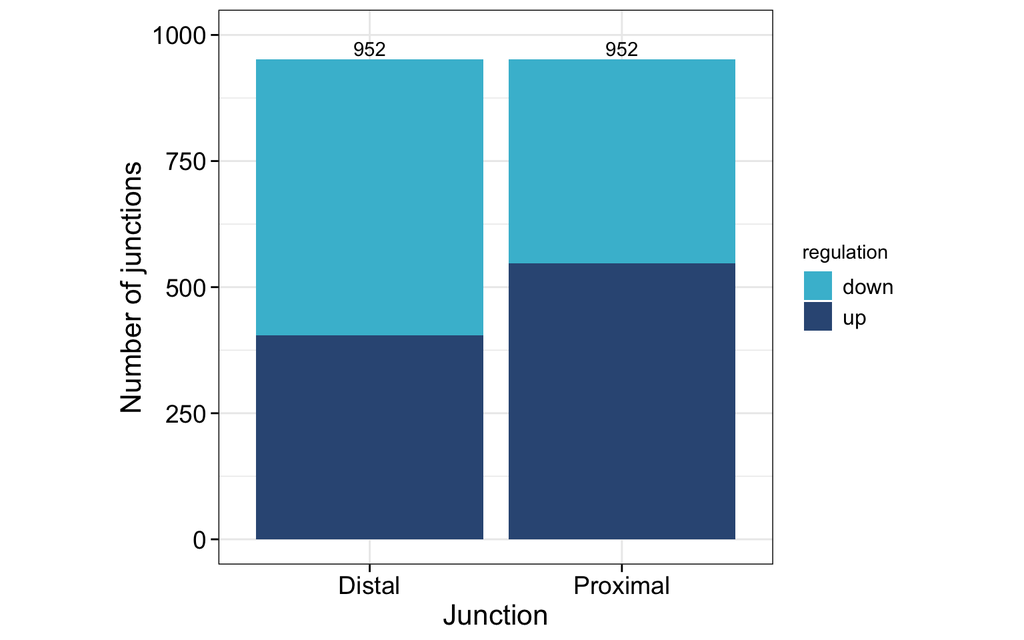

```r
regulationDF %>%
          dplyr::filter(regulation %in% c("up", "down")) %>%
    dplyr::count(junction_name, regulation) %>%
    ggplot(., aes(x=junction_name, y=n, fill=regulation)) +
    geom_col() +
    scale_y_continuous(breaks=seq(0,1000,250), limits=c(0,1000)) +
    scale_fill_manual(values=c("up" = "#345784", "no" = "lightgrey", "down" = "#45bcd4")) +
    geom_text(aes(label = stat(y), group = junction_name), stat = 'summary', fun = sum, vjust = -.25) +
    labs(x="Junction", y="Number of junctions") +
    myTheme + theme(legend.position = "right",
                    aspect.ratio=1)
```

```r
# Group sizes
kable(regulationDF %>% count(junction_name, regulation), align="c")
```

| junction_name | regulation | n |
| --- | --- | --- |
| Distal | no | 7536 |
| Distal | down | 547 |
| Distal | up | 405 |
| Proximal | no | 7536 |
| Proximal | down | 405 |
| Proximal | up | 547 |

## 4.2 Annotation information of distal and proximal junctions

Next, the annotaiton status of the distal and proximal junctions of each regulated A5SS event was determined, which is provided in the “denovo” column of the Voila modulizer output.

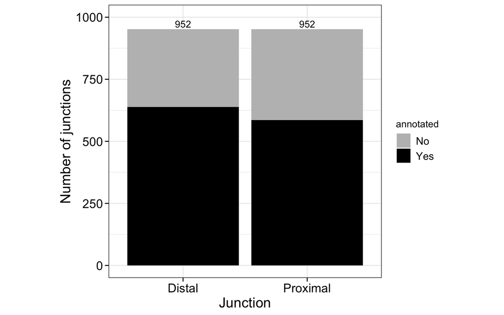

```r
regulationDF %>%
    dplyr::filter(regulation %in% c("up", "down")) %>%
    dplyr::rename(annotated = denovo) %>%
    mutate(annotated=ifelse(annotated == "True", "No", "Yes")) %>%
    dplyr::count(junction_name, annotated) %>%
    ggplot(., aes(x=junction_name, y=n, fill=annotated)) +
        geom_col() +
        scale_y_continuous(breaks=seq(0,1000,250), limits=c(0,1000)) +
        scale_fill_manual(values=c("No" = "grey", "Yes" = "black")) +
        geom_text(aes(label = stat(y), group = junction_name), stat = 'summary', fun = sum, vjust = -.25) +
        labs(x="Junction", y="Number of junctions") +
        myTheme + theme(legend.position = "right",
                        aspect.ratio = 1)
```

Around 2/3 of the junctions are annotated with slightly more distal junctions being annotated.

In addition, the annotation status of junction pairs was determined.

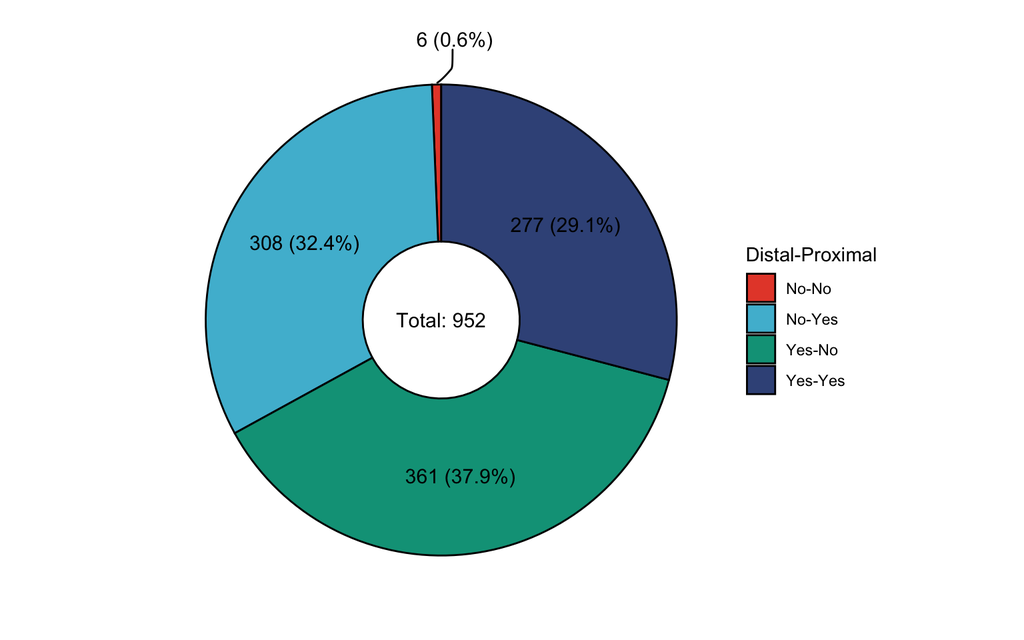

```r
regulationDF %>%
    dplyr::filter(regulation %in% c("up", "down")) %>%
    dplyr::rename(annotated = denovo) %>%
    mutate(annotated=ifelse(annotated == "True", "No", "Yes")) %>%
    group_by(event_id) %>%
    arrange(junction_name) %>%
    summarize(Distal_Proximal=paste0(annotated, collapse="-")) %>%
    dplyr::count(Distal_Proximal) %>%
    arrange(Distal_Proximal) %>%
    dplyr::rename(count=n) %>%
    ggpie::ggdonut(., group_key = "Distal_Proximal", count_type = "count",
        label_info = "all", label_type = "horizon", label_split = NULL,
        label_size = 4, label_pos = "in", labal_threshold = 10,
        donut.label.color = "black") +
    scale_fill_npg(name="Distal-Proximal")
```

Only 6 events exist for which none of the two junctions is known, 29.1% of the events have both junctions annotated and 70.3% of the events have either the distal or proximal junction annotated.

Further, the annotation status was checked with respect to the regulation of the junctions. For this purpose, the 1904 junctions of regulated events were considered as either up- or downregulated and the fraction of annotated junctions determined for both sets.

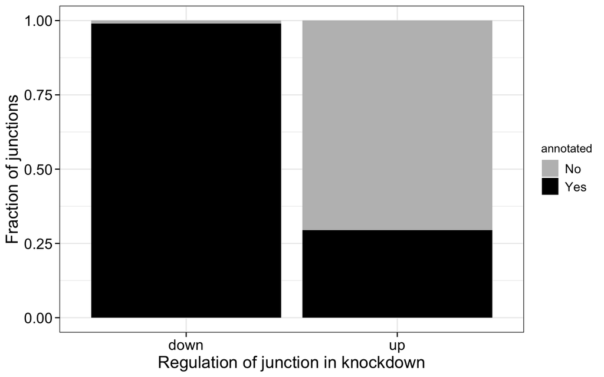

```r
regulationDF %>%
    dplyr::filter(regulation %in% c("up", "down")) %>%
    dplyr::rename(annotated = denovo) %>%
    mutate(annotated=ifelse(annotated == "True", "No", "Yes")) %>%
    group_by(regulation) %>%
    summarize(Yes=sum(annotated == "Yes") / n(),
              No=sum(annotated == "No") / n()) %>%
    pivot_longer(cols=2:3, names_to="annotated", values_to = "fraction") %>%
    ggplot(., aes(x=regulation, y=fraction, fill=annotated)) +
    geom_col() +
    scale_fill_manual(values=c("No" = "grey", "Yes" = "black")) +
    labs(x="Regulation of junction in knockdown",
         y="Fraction of junctions") +
    myTheme + theme(legend.position = "right")
```

```r
regulationDF %>%
    dplyr::filter(regulation %in% c("up", "down")) %>%
    dplyr::rename(annotated = denovo) %>%
    mutate(annotated=ifelse(annotated == "True", "No", "Yes")) %>%
    group_by(regulation) %>%
    summarize(Fraction_anno=sum(annotated == "Yes") / n(),
              Total_anno = sum(annotated == "Yes"),
              Fraction_non_anno=sum(annotated == "No") / n(),
              Total_non_anno = sum(annotated == "No")) %>%
    kable(., "html") %>% kableExtra::kable_styling("striped") %>% kableExtra::scroll_box(width = "100%")
```

| regulation | Fraction_anno | Total_anno | Fraction_non_anno | Total_non_anno |
| --- | --- | --- | --- | --- |
| down | 0.9894958 | 942 | 0.0105042 | 10 |
| up | 0.2951681 | 281 | 0.7048319 | 671 |

Out of the downregulated junctions about 99% are annotated, while only ~30% for the upregulated junctions are annotated.

## 4.3 Biotype of genes harboring A5SS events

The biotype of the genes harboring the regulated A5SS events was inferred from the Gencode GFF3-File.

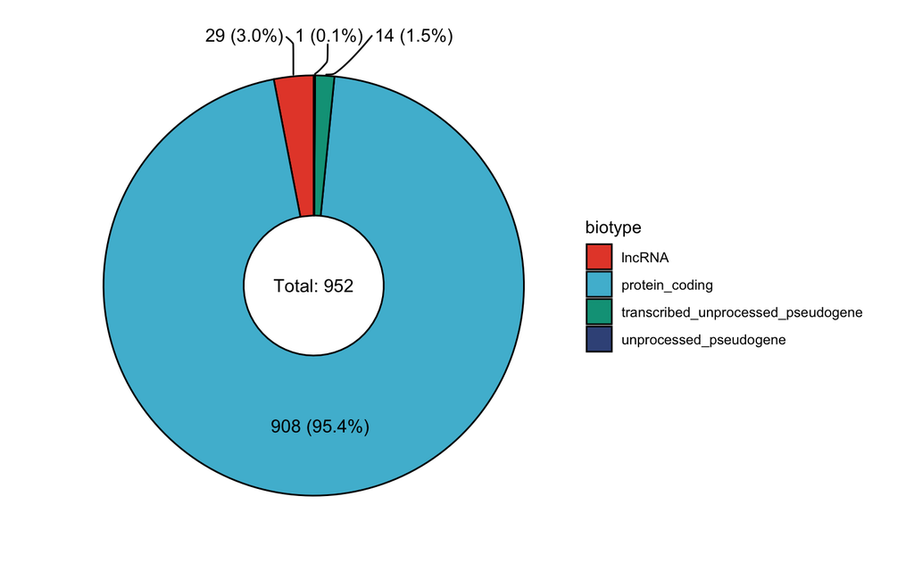

```r
anno <- import("data/gencode.v38.annotation.gff3")
biotype_to_gene <- anno[anno$type == "gene"] %>% as.data.frame %>%
    dplyr::select(ID, gene_type) %>% dplyr::rename(gene_id = ID, biotype = gene_type)

regulationDF$gene_id <- regulationDF$event_id %>% strsplit(., "_", fixed=TRUE) %>% sapply(., "[[", 1)

regulationDF <- left_join(regulationDF, biotype_to_gene)

regulationDF %>% dplyr::filter(regulation %in% c("up", "down") & junction_name == "Proximal") %>%
    count(biotype) %>%
    arrange(biotype) %>%
    dplyr::rename(count=n) %>%
    ggpie::ggdonut(., group_key = "biotype", count_type = "count",
        label_info = "all", label_type = "horizon", label_split = NULL,
        label_size = 4, label_pos = "in", labal_threshold = 10,
        donut.label.color = "black") +
    scale_fill_npg(name="biotype")
```

The vast majority of A5SS events is located in transcripts of protein-coding genes.

## 4.4 Generation of GRanges objects for A5SS events

For upcoming analyses each A5SS event is stored as a GRanges object, which is comprised by the three involved exons:

- E1P: Exon coordinates of the upstream exon when the proximal junction is used (longer version)
- E1D: Exon coordinates of the upstream exon when the distal junction is used (shorter version)
- E2: Exon coordinates of the downstream exon

The GRangesList is stored as RDS-File.

```r
if(!file.exists("rds_files/A5SSranges.rds")){

    candidateIDs <- regulatedEvents %>%
        dplyr::filter(eventClass == "alt5prime") %>%
        pull(event_id)

    A5SSevents <- binaryEvents$alt5prime %>%
        dplyr::filter(event_id %in% candidateIDs)

    A5SSranges <- lapply(split(A5SSevents, A5SSevents$event_id), function(df){

        df <- df %>%
            dplyr::rename(chr=seqid, exon=spliced_with)

        tmpE1 <- df$reference_exon_coord %>% unique %>% strsplit(., "-", fixed=T) %>% unlist %>% as.integer
        tmpE2 <- df$spliced_with_coord %>% unique %>% strsplit(., "-", fixed=T) %>% unlist %>% as.integer

        gr <- data.frame(chr=df$chr[1],
                          strand=df$strand[1],
                          start=c(tmpE1[1], tmpE2[1]),
                          end=c(tmpE1[2], tmpE2[2])) %>%
            makeGRangesFromDataFrame() %>%
            sort

        if(df$strand[1] == "+"){
            gr$exon <- c("E1P", "E2")
        } else {
            gr$exon <- c("E2", "E1P")
        }

        gr <- c(gr, gr[gr$exon == "E1P"])

        if(df$strand[1] == "+"){
            end(gr)[3] <- df %>% dplyr::filter(junction_name == "Distal") %>% pull(junction_coord) %>% strsplit(., "-", fixed=T) %>% sapply(., "[[", 1) %>% as.integer
            gr$exon[3] <- "E1D"
        } else {
            start(gr)[3] <- df %>% dplyr::filter(junction_name == "Distal") %>% pull(junction_coord) %>% strsplit(., "-", fixed=T) %>% sapply(., "[[", 2) %>% as.integer
            gr$exon[3] <- "E1D"
        }

        gr <- gr %>% sort()

        gr$module_id <- df$module_id[1]
        gr$event_id <- df$event_id[1]
        gr$lsv_id <- df$lsv_id[1]
        gr$gene_id <- df$gene_id[1]
        gr$gene_name <- df$gene_name[1]
        gr$event_size <- df$event_size[1]

        gr$CT_median_psi <- NA
        gr$CT_median_psi[gr$exon == "E1P"] <- df$CT_median_psi[df$junction_name=="Proximal"]
        gr$CT_median_psi[gr$exon == "E1D"] <- df$CT_median_psi[df$junction_name=="Distal"]

        gr$KD_median_psi <- NA
        gr$KD_median_psi[gr$exon == "E1P"] <- df$KD_median_psi[df$junction_name=="Proximal"]
        gr$KD_median_psi[gr$exon == "E1D"] <- df$KD_median_psi[df$junction_name=="Distal"]

        gr$KD.CT_median_dpsi <- NA
        gr$KD.CT_median_dpsi[gr$exon == "E1P"] <- df$KD.CT_median_dpsi[df$junction_name=="Proximal"]
        gr$KD.CT_median_dpsi[gr$exon == "E1D"] <- df$KD.CT_median_dpsi[df$junction_name=="Distal"]

        gr$KD.CT_probability_changing <- NA
        gr$KD.CT_probability_changing[gr$exon == "E1P"] <- df$KD.CT_probability_changing[df$junction_name=="Proximal"]
        gr$KD.CT_probability_changing[gr$exon == "E1D"] <- df$KD.CT_probability_changing[df$junction_name=="Distal"]

        gr$denovo <- NA
        gr$denovo[gr$exon == "E1P"] <- df$denovo[df$junction_name=="Proximal"]
        gr$denovo[gr$exon == "E1D"] <- df$denovo[df$junction_name=="Distal"]

        return(gr)
    }) %>% as(., "GRangesList")

    saveRDS(A5SSranges, "rds_files/A5SSranges.rds")
} else {
    A5SSranges <- readRDS("rds_files/A5SSranges.rds")
}
```

## 4.5 Overlaps with CDSs

Based on the shorter upstream exon (E1D) overlaps with annoated CDSs were determined.

```r
CDS <- anno %>% plyranges::filter(type=="CDS" & transcript_type == "protein_coding")

A5SSranges <- A5SSranges[names(A5SSranges) %in%
                              (regulationDF %>% dplyr::filter(
                                  regulation %in% c("up", "down") &
                                      junction_name == "Proximal" &
                                      biotype == "protein_coding") %>%
                                   pull(event_id))]

E1Dranges <- endoapply(A5SSranges, function(gr){
    gr <- gr[gr$exon == "E1D"]
    return(gr)
}) %>% unlist

anyOverlaps <- findOverlaps(E1Dranges, CDS, type="any") %>% as.data.frame()

phaseInfoRanges <- lapply(split(anyOverlaps, anyOverlaps$queryHits), function(df){

    gr1 <- E1Dranges[df$queryHits[1]]

    tmpCDS <- CDS[df$subjectHits]

    tmpCDS <- tmpCDS[tmpCDS$gene_id == gr1$gene_id]

    if(length(tmpCDS) == 0){return(data.frame())}

    phaseInfo <- tmpCDS %>%
        as.data.frame(., stringsAsFactors=FALSE) %>%
        dplyr::select(seqnames, strand, start, end, width, strand, type, phase, gene_id, gene_name) %>%
        mutate(across(where(is.factor), as.character)) %>%
        mutate(phase=factor(phase, levels=c(0,1,2))) %>%
        count(seqnames, strand, start, end, phase, .drop=FALSE) %>% pivot_wider(., names_from=phase, values_from=n) %>%
        rowwise() %>%
        mutate(phaseSum=sum(c_across(5:7))) %>%
        ungroup

    gr2 <- phaseInfo %>% makeGRangesFromDataFrame(keep.extra.columns = T)
    phaseInfo$length_overlap <- pintersect(rep(gr1, length(gr2)), gr2) %>% width

    phaseInfo <- phaseInfo %>% arrange(desc(length_overlap), desc(phaseSum)) %>% dplyr::slice(1)
    phaseInfo$event_id <- gr1$event_id
    phaseInfo$length_E1D <- gr1 %>% width

    return(phaseInfo)
}) %>% bind_rows() %>% makeGRangesFromDataFrame(., keep.extra.columns = TRUE)
```

The number of protein-coding gene overlapping A5SS events with an assigned CDS exon is shown below. Note that those events lacking a CDS are located in 5’ or 3’ UTRs.

```r
data.frame(overlap=c(TRUE, FALSE), count=c(length(phaseInfoRanges), length(E1Dranges) - length(phaseInfoRanges))) %>%
    arrange(overlap) %>%
    ggpie::ggdonut(., group_key = "overlap", count_type = "count",
        label_info = "all", label_type = "horizon", label_split = NULL,
        label_size = 4, label_pos = "in", labal_threshold = 10,
        donut.label.color = "black") +
    scale_fill_npg(name="overlap with CDS exon")
```

[figure not shown]

## 4.6 Adjusting distal/proximal exon 5’ ends

5’ ends of the upstream exons (E1D and E1P) were truncated such the phase is 0. This step is necessary for the upcoming in silico translation.

```r
# Adjust exon boundaries
adjustedA5SSranges <- endoapply(A5SSranges, function(gr){

    if(!gr$event_id[1] %in% phaseInfoRanges$event_id){return(GRanges())}

    #print(gr$event_id[1])

    #Get matched CDS exon
    grMatched <- phaseInfoRanges[phaseInfoRanges$event_id == gr$event_id[1]]

    #Remove nucleotides from matched CDS exon so the phase is 0
    nucleotidesToRemove <- which.max(c(mcols(grMatched)[,1], mcols(grMatched)[,2], mcols(grMatched)[,3])) - 1
    grMatched <- resize(grMatched, width = width(grMatched) - nucleotidesToRemove, fix="end")

    if(strand(gr) %>% as.character == "+" & start(gr[gr$exon == "E1D"]) <= start(grMatched)){
        start(gr[gr$exon %in% c("E1D", "E1P")]) <- start(grMatched)
    } else if(strand(gr) %>% as.character == "+" & start(gr[gr$exon == "E1D"]) > start(grMatched)){

        diff <- start(gr[gr$exon == "E1D"]) - start(grMatched)
        nucleotidesToRemove <- 3 - diff %% 3
        start(gr[gr$exon %in% c("E1D", "E1P")]) <- start(gr[gr$exon %in% c("E1D", "E1P")]) + nucleotidesToRemove

    } else if(strand(gr) %>% as.character == "-" & end(gr[gr$exon == "E1D"]) >= end(grMatched)){
        end(gr[gr$exon %in% c("E1D", "E1P")]) <- end(grMatched)
    } else if(strand(gr) %>% as.character == "-" & end(gr[gr$exon == "E1D"]) < end(grMatched)){
        diff <- end(grMatched) - end(gr[gr$exon == "E1D"])
        nucleotidesToRemove <- 3 - diff %% 3
        end(gr[gr$exon %in% c("E1D", "E1P")]) <- end(gr[gr$exon %in% c("E1D", "E1P")]) - nucleotidesToRemove
    }
    return(gr)
})
```

## 4.7 Inference of peptide sequences and stop codons

For the two upstream exons (E1D and E1P) the nucleotide sequence is extracted and did translated into an AA sequence. If a stop codon (*) is located in the AA sequence, everything after the stop codon is removed. Peptide sequences are stored together with additional information in a data.frame.

```r
peptideDF <- lapply(adjustedA5SSranges, function(gr){

    if(length(gr) == 0){return(data.frame())}

    E1D_seq <- getSeq(Hsapiens, gr[gr$exon == "E1D"])
    E1P_seq <- getSeq(Hsapiens, gr[gr$exon == "E1P"])


    E1D_AAseq <- translate(E1D_seq, no.init.codon=TRUE) %>% as.character  # no.init.codon=TRUE as otherwise CTG will be M instead of L
    E1P_AAseq <- translate(E1P_seq, no.init.codon=TRUE) %>% as.character

    hasStopCodon <- grepl("*", c(E1D_AAseq, E1P_AAseq), fixed=T)

    E1D_AAseq <- E1D_AAseq %>% strsplit(., "*", fixed=TRUE) %>% sapply("[[", 1)
    E1P_AAseq <- E1P_AAseq %>% strsplit(., "*", fixed=TRUE) %>% sapply("[[", 1)
    #Speichern ob Stern da war

    return(
        data.frame(
            chr = seqnames(gr[1]) %>% as.character,
            strand = strand(gr[1]) %>% as.character,
            start_E1 = start(gr[match(c("E1D", "E1P"), gr$exon)]),
            end_E1 = end(gr[match(c("E1D", "E1P"), gr$exon)]),
            start_E2 = start(gr[match("E2", gr$exon)]),
            end_E2 = end(gr[match("E2", gr$exon)]),
            event_id = gr$event_id[1],
            lsv_id = gr$lsv_id[1],
            A5SS = c("Distal", "Proximal"),
            psiCT = gr$CT_median_psi[match(c("E1D", "E1P"), gr$exon)],
            psiKD = gr$KD_median_psi[match(c("E1D", "E1P"), gr$exon)],
            dpsi = gr$KD.CT_median_dpsi[match(c("E1D", "E1P"), gr$exon)],
            event_size = gr$event_size[1],
            peptide_seq = c(E1D_AAseq, E1P_AAseq),
            peptide_len = c(nchar(E1D_AAseq), nchar(E1P_AAseq)),
            frame_shift = !(gr$event_size[match(c("E1D", "E1P"), gr$exon)] %% 3 == 0),
            stop_codon = hasStopCodon
    ))

}) %>% bind_rows()

kable(peptideDF[1:5,], "html") %>% kableExtra::kable_styling("striped") %>% kableExtra::scroll_box(width = "100%")
```

chr

strand

start_E1

end_E1

start_E2

end_E2

event_id

lsv_id

A5SS

psiCT

psiKD

dpsi

event_size

peptide_seq

peptide_len

frame_shift

stop_codon

chr7

92397725

92397769

92398212

92401383

ENSG00000001629.10_5_A5_1

ENSG00000001629.10:s:92397723-92397859

Distal

0.084

0.223

0.128

90

IPEGGSSSRRPGTSV

15

FALSE

FALSE

chr7

92397725

92397859

92398212

92401383

ENSG00000001629.10_5_A5_1

ENSG00000001629.10:s:92397723-92397859

Proximal

0.916

0.777

-0.128

90

IPEGGSSSRRPGTSVVSSASMSVLHSSSLRDYTPASRSENQDSLQ

45

FALSE

FALSE

chr17

48112044

48112085

48112574

48112660

ENSG00000002919.15_2_A5_2

ENSG00000002919.15:s:48111949-48112455

Distal

0.921

0.621

-0.299

26

MGFWCRMSENQEQE

14

TRUE

FALSE

chr17

48112044

48112111

48112574

48112660

ENSG00000002919.15_2_A5_2

ENSG00000002919.15:s:48111949-48112455

Proximal

0.078

0.284

0.205

26

MGFWCRMSENQEQEVRVWSAEN

22

TRUE

FALSE

chr3

50090435

50090451

50092043

50092208

ENSG00000003756.17_2_A5_1

ENSG00000003756.17:s:50090370-50090464

Distal

0.999

0.821

-0.156

13

MGSDK

5

TRUE

FALSE

## 4.8 Frameshift information

For those A5SS events overlapping a CDS exon, the frameshift pontential is determined by checking if the distance between the distal and proximal junction is a multiple of 3 or not.

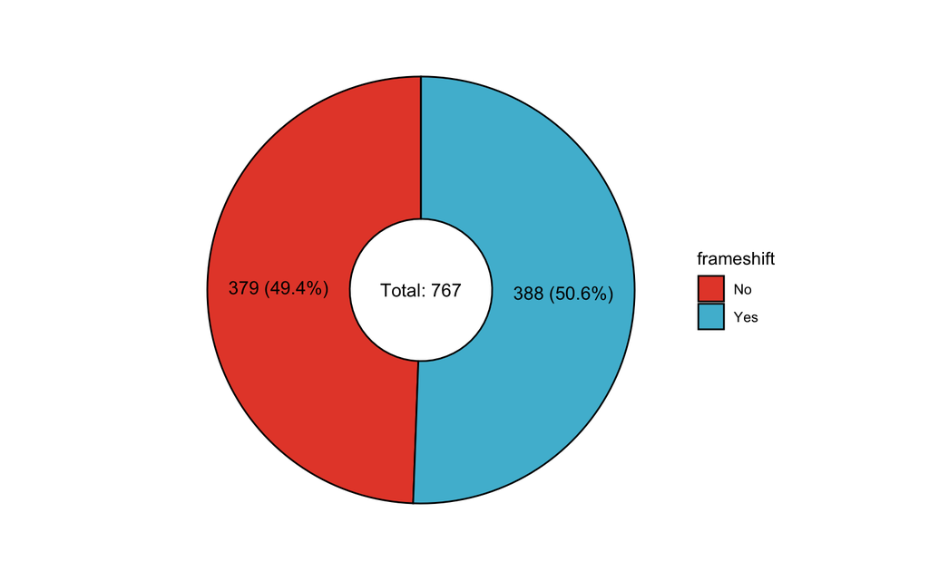

```r
frameShiftDF <- peptideDF %>%
    dplyr::filter(A5SS=="Proximal") %>%
    mutate(frameshift = factor(ifelse(event_size %% 3 == 0, "No", "Yes"), levels=c("No", "Yes")))

# Donut

frameShiftDF %>%
    dplyr::count(frameshift) %>%
    arrange(frameshift) %>%
    dplyr::rename(count=n) %>%
    ggpie::ggdonut(., group_key = "frameshift", count_type = "count",
        label_info = "all", label_type = "horizon", label_split = NULL,
        label_size = 4, label_pos = "in", labal_threshold = 10,
        donut.label.color = "black") +
    scale_fill_npg(name="frameshift")
```

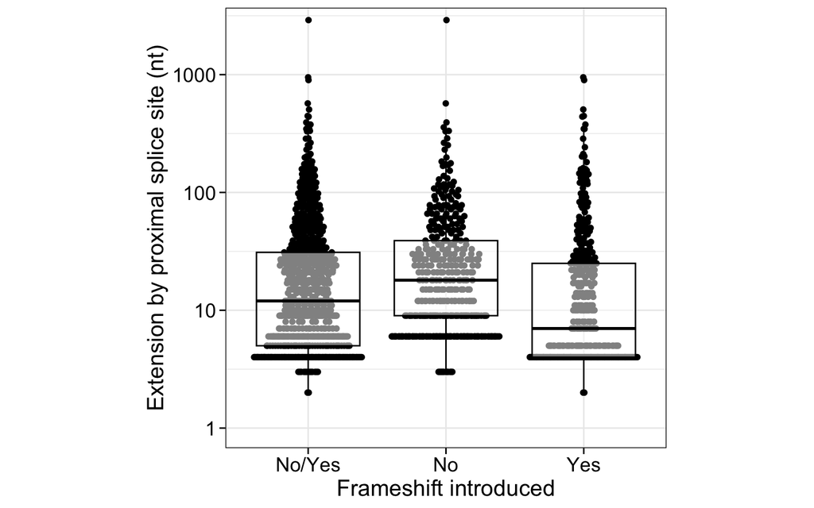

```r
# Boxplot
rbind(frameShiftDF %>% mutate(frameshift = "No/Yes"),
      frameShiftDF) %>%
    mutate(frameshift = factor(frameshift, levels=c("No/Yes", "No", "Yes"))) %>%
    ggplot(., aes(x=frameshift, y=event_size)) +
    geom_quasirandom() +
    geom_boxplot(alpha=.5, outlier.size = -1, col="black") +
    scale_y_log10(breaks=c(1,10,100,1000)) +
    coord_cartesian(ylim=c(1,2500)) +
    labs(x="Frameshift introduced", y="Extension by proximal splice site (nt)") +
    myTheme + theme(aspect.ratio=1)
```

## 4.9 Final classification of events

In the final step, A5SS events were classified based on the following 3 features:

- Frameshift (TRUE / FALSE)
- Stop codon introduced by one of the two A5SSs (TRUE / FALSE)
- Change in exon length (shortened = distal up / elongated = proximal up)

At first, I the frequency of the 8 possible combinations was determined.

```r
classificationDF <- peptideDF %>% group_by(event_id) %>%
    summarize(event_id=unique(event_id),
              frameshift = unique(!event_size %% 3 == 0),
              stop = any(stop_codon),
              exon_length=ifelse(dpsi[1] > 0, "shortened", "elongated"))

head(classificationDF)
```

```
## # A tibble: 6 × 4
##   event_id                  frameshift stop  exon_length
##   <chr>                     <lgl>      <lgl> <chr>
## 1 ENSG00000001629.10_5_A5_1 FALSE      FALSE shortened
## 2 ENSG00000002919.15_2_A5_2 TRUE       FALSE elongated
## 3 ENSG00000003756.17_2_A5_1 TRUE       TRUE  elongated
## 4 ENSG00000003756.17_6_A5_1 TRUE       FALSE elongated
## 5 ENSG00000003756.17_8_A5_1 FALSE      FALSE elongated
## 6 ENSG00000004142.12_1_A5_1 TRUE       TRUE  elongated
```

```r
classificationDF %>% count(frameshift, stop, exon_length) %>% mutate (case=paste0("case", 1:8))
```

```
## # A tibble: 8 × 5
##   frameshift stop  exon_length     n case
##   <lgl>      <lgl> <chr>       <int> <chr>
## 1 FALSE      FALSE elongated     173 case1
## 2 FALSE      FALSE shortened     186 case2
## 3 FALSE      TRUE  elongated      17 case3
## 4 FALSE      TRUE  shortened       3 case4
## 5 TRUE       FALSE elongated     172 case5
## 6 TRUE       FALSE shortened     131 case6
## 7 TRUE       TRUE  elongated      73 case7
## 8 TRUE       TRUE  shortened      12 case8
```

The final groups are:

- elongated (case 1)
- shortened (case 2)
- disruped (case3 to case8)

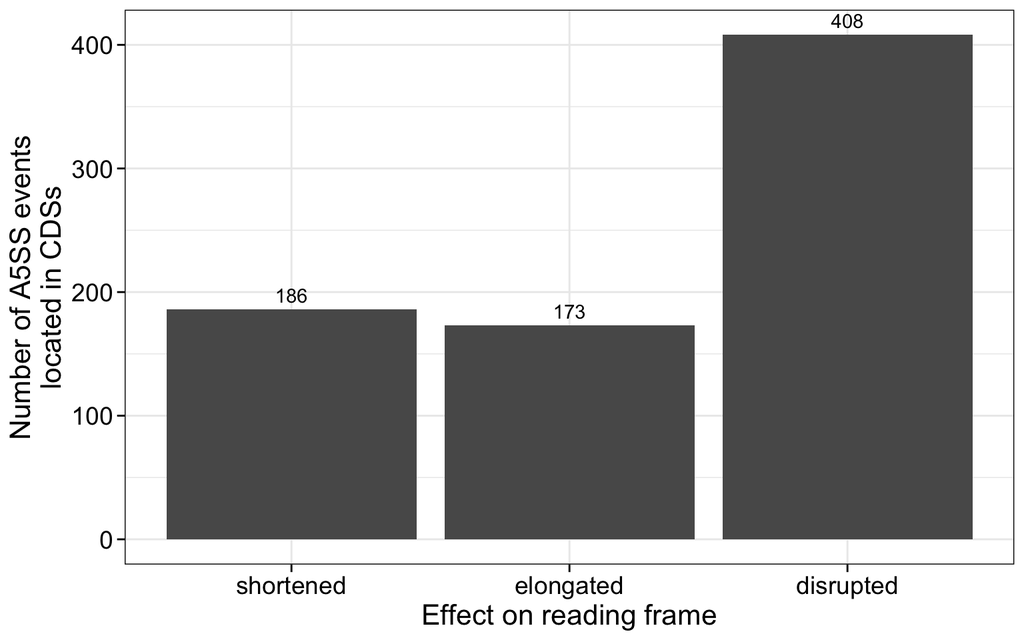

```r
classificationDF <- classificationDF %>%
    mutate(group = case_when(!frameshift & !stop & exon_length == "elongated" ~ "elongated",
                             !frameshift & !stop & exon_length == "shortened" ~ "shortened",
                             TRUE ~ "disrupted")
           )


classificationDF %>% count(group) %>%
    mutate(group = factor(group, levels=c("shortened", "elongated", "disrupted"))) %>%
    ggplot(., aes(x=group, y=n)) +
    geom_col() +
    labs(x="Effect on reading frame", y="Number of A5SS events\nlocated in CDSs") +
    geom_text(aes(label=n), vjust=-.5) +
    myTheme
```

```r
classificationDF %>% count(group)
```

```
## # A tibble: 3 × 2
##   group         n
##   <chr>     <int>
## 1 disrupted   408
## 2 elongated   173
## 3 shortened   186
```

The underlying data.frame is stored and used in upcoming analyses.

```r
saveRDS(classificationDF, "rds_files/classificationDF.rds")
```

# 5 XLSX-Files

A XLSX-File with all genes containing an A5SS event and group membership is prepared.

```r
xlsx1 <- lapply(classificationDF$event_id, function(eventID){
    tmpDF <- classificationDF %>% dplyr::filter(event_id == eventID)
    gr <- A5SSranges[[eventID]]
    exon_order = c(which(gr$exon == "E1D"), which(gr$exon == "E1P"), which(gr$exon == "E2"))

    data.frame(gene_id = gr$gene_id[1],
               gene_name = gr$gene_name[1],
               event_id = eventID,
               event_size = gr$event_size[1],
               strand = strand(gr[1]) %>% as.character,
               chr = seqnames(gr[1]) %>% as.character,
               has_frameshift = tmpDF$frameshift,
               has_stop = tmpDF$stop,
               KD_effect_exon_length = tmpDF$exon_length,
               classification = tmpDF$group,
               exon_E1D = paste0(ranges(gr[exon_order[1]]) %>% start, "-", ranges(gr[exon_order[1]]) %>% end),
               exon_E1P = paste0(ranges(gr[exon_order[2]]) %>% start, "-", ranges(gr[exon_order[2]]) %>% end),
               exon_E2 = paste0(ranges(gr[exon_order[3]]) %>% start, "-", ranges(gr[exon_order[3]]) %>% end),
               PSI_CT_E1D = gr[exon_order[1]]$CT_median_psi,
               PSI_CT_E1P = gr[exon_order[2]]$CT_median_psi,
               PSI_KD_E1D = gr[exon_order[1]]$KD_median_psi,
               PSI_KD_E1P = gr[exon_order[2]]$KD_median_psi,
               dPSI_E1D = gr[exon_order[1]]$KD.CT_median_dpsi,
               dPSI_E1P = gr[exon_order[2]]$KD.CT_median_dpsi)
}) %>% bind_rows()

xlsx::write.xlsx2(xlsx1, "xlsx_files/final_767_A5SS_events.xlsx", row.names = F)
```

In addition, a XLSX-File providing for each AS event class the genes with at least one regulated event of this class is prepared.

```r
xlsx2 <- regulatedEvents %>%
    dplyr::select(eventClass, gene_name, event_id) %>%
    dplyr::rename(AS_event_type = eventClass)

xlsx::write.xlsx2(xlsx2, "xlsx_files/all_1956_regulated_AS_events.xlsx", row.names = F)
```